# 20210224_DEG_heatmap

Gijsje

2/24/2021

# DEG across stimulations FDR % log FC > 1 or -1

#1204 genes

```r
LPS <- read.csv("~/Documents/MiGASti/Databases/res_name_LPS_LFC1.txt", sep="")
IFNy <- read.csv("~/Documents/MiGASti/Databases/res_name_IFNy_LFC1.txt", sep="")
R848 <- read.csv("~/Documents/MiGASti/Databases/res_name_R848_LFC1.txt", sep="")
TNFa <- read.csv("~/Documents/MiGASti/Databases/res_name_TNFa_LFC1.txt", sep="")
DEX <- read.csv("~/Documents/MiGASti/Databases/res_name_DEX_LFC1.txt", sep="")
IL4 <- read.csv("~/Documents/MiGASti/Databases/res_name_IL4_LFC1.txt", sep="")
ATP <- read.csv("~/Documents/MiGASti/Databases/res_name_ATP_LFC1.txt", sep="")

genes_LPS <- LPS$ensembl
genes_ATP <- ATP$ensembl
genes_R848 <- R848$ensembl
genes_IFNy <- IFNy$ensembl
genes_DEX <- DEX$ensembl
genes_IL4 <- IL4$ensembl
genes_TNFa <- TNFa$ensembl

# create a vector with all genes listed
x <- c(genes_LPS, genes_ATP, genes_R848, genes_IFNy, genes_DEX, genes_IL4, genes_TNFa)
# make a dataframe
as.data.frame(x) #1325 genes
# check if there are genes duplicate
duplicated(x)
unique(x)
#remove duplicated
ensembl <- x[!duplicated(x)] #1204 genes

genelist <- as.data.frame(ensembl)
ensembl <- genelist$ensembl[!duplicated(genelist$ensembl)]
genelist <- as.data.frame(ensembl)
genelist %>% distinct(ensembl, .keep_all = TRUE)

load("~/Documents/MiGASti/res_name_LPS2.Rdata")
load("~/Documents/MiGASti/docs/res_name_IFNy2.Rdata")
load("~/Documents/MiGASti/Databases/res_name_TNFa2.Rdata")
load("~/Documents/MiGASti/Databases/res_name_R8482.Rdata")
load("~/Documents/MiGASti/Databases/res_name_IL42.Rdata")
load("~/Documents/MiGASti/Databases/res_name_ATP2.Rdata")
load("~/Documents/MiGASti/Databases/res_name_DEX2.Rdata")

DEG_genes_LPS = merge(res_name_LPS2, genelist, by ="ensembl")
DEG_genes_IFNy = merge(res_name_IFNy2, genelist, by = "ensembl")
DEG_genes_IL4 = merge(res_name_IL42, genelist, by = "ensembl")
DEG_genes_R848 = merge(res_name_R8482, genelist, by = "ensembl")
DEG_genes_ATP = merge(res_name_ATP2, genelist, by = "ensembl")
DEG_genes_DEX = merge(res_name_DEX2, genelist, by = "ensembl")
DEG_genes_TNFa = merge(res_name_TNFa2, genelist, by = "ensembl")

Expression_stimulations <- cbind(DEG_genes_LPS, DEG_genes_IFNy, DEG_genes_IL4, DEG_genes_R848, DEG_genes_ATP, DEG_genes_DEX, DEG_genes_TNFa)

as.data.frame(Expression_stimulations)
# changes names in data frame
names(Expression_stimulations)[2] <- "LPS"
names(Expression_stimulations)[10] <- "IFNy"
names(Expression_stimulations)[18] <- "IL4"
names(Expression_stimulations)[26] <- "R848"
names(Expression_stimulations)[34] <- "ATP"
names(Expression_stimulations)[42] <- "DEX"
names(Expression_stimulations)[50] <- "TNFa"

DF_log2FC <- Expression_stimulations %>% select(1, 2, 10, 18, 26, 34, 42, 50)
DF <- as.data.frame(DF_log2FC)
DF <- t(DF)
head( DF )[,1:10]

# fill NA with 0
DF_log2FC[is.na(DF_log2FC)] = 0
#save(DF_log2FC, file = "Kmeans1204gsupport.Rdata")

gencode <- read.delim("~/Documents/MiGASti/Databases/ens.geneid.gencode.v30")
gencode$ensembl = gencode$gene_id
DF_log2FC <- merge(gencode, DF_log2FC, by = "ensembl")
DF_log2FC$symbol = DF_log2FC$GeneSymbol

# remove the first column
df_num = as.matrix(DF_log2FC[,4:10])
# scale the data
df_num_scale = scale(df_num)
save(df_num, file = "df_num_logFC1stim.Rdata")
#save(DF_log2FC, file = "LOGFC1_stimulations.Rdata")
#save(df_num_scale, file = "df_num_scale_LOGFC1stim.Rdata")
```

### Overlap 1204 genes with Patir

```r
gencode <- read.delim("~/Documents/MiGASti/Databases/ens.geneid.gencode.v30")
gencode$ensembl = gencode$gene_id
genelist <- merge(gencode, genelist, by = "ensembl")
genelist$symbol = genelist$GeneSymbol
Patir <- read.csv("~/Documents/MiGASti/Databases/Patir.txt", sep="")
names(Patir)[1] <- "symbol"
overlap1 <- merge(Patir, genelist, by = "symbol")
list(overlap1$symbol)
```

[[1]] [1] “ADORA3” “AIF1” “ALOX5AP” “ARHGAP25” “C1QB” “C1QC”  
[7] “C2” “C3AR1” “CD300A” “CIITA” “CTSC” “EBI3”  
[13] “FCGR1A” “FCGR1B” “FGD2” “FGL2” “FPR1” “GIMAP2”  
[19] “GPR183” “HAMP” “IFI30” “IL13RA1” “IRF5” “LILRB2”  
[25] “LY86” “LYL1” “MPEG1” “MS4A4A” “P2RY12” “RHBDF2”  
[31] “SAMSN1” “SELPLG” “SIGLEC10” “SIRPB2” “SLC2A5” “SLC37A2” [37] “SUCNR1” “SYTL3” “TLR2” “TNFSF8” “TRIM22”

### Heatmap DEG

#1204 genes (scaling data and additional row scaling)

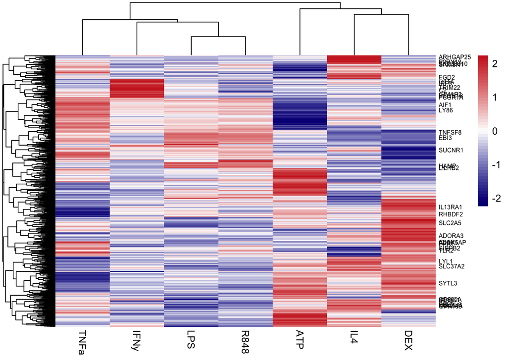

```r
rownames(DF_log2FC) = DF_log2FC$symbol
genelist <- c("ADORA3", "AIF1", "C2", "ALOX5AP", "ARHGAP25", "C2", "C3AR1", "CD300A", "CIITA", "EBI3", "FCGR1A", "FCGR1B", "FGD2", "FGL2", "FPR1", "GIMAP2", "GPR183", "HAMP", "IFI30", "IL13RA1", "IRF5", "LILRB2", "LY86", "LYL1", "MPEG1", "MS4A4A", "P2RY12", "RHBDF2", "SAMSN1", "SELPLG", "SIGLEC10", "SIRPB2", "SLC2A5", "SLC37A2", "SUCNR1", "SYTL3", "TLR2", "TNFSF8", "TRIM22")

labels <- rownames(DF_log2FC)
labels[!labels %in% genelist] <- ""
pheatmap(df_num_scale, scale="row", labels_row = labels, fontsize_row = 6, color = colorRampPalette(c("navy", "white", "firebrick3"))(50))
```

### Correlation plot DEG (Spearman)

#1204 genes

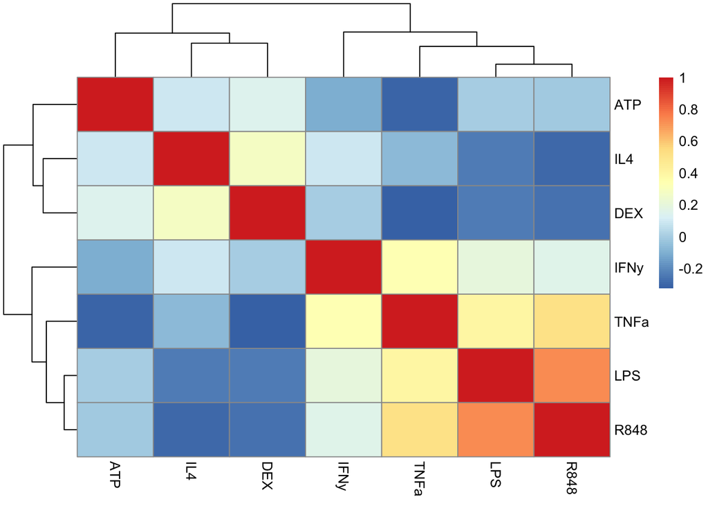

```r
com = DF_log2FC[,4:10]
cc = cor(com, method = "spearman")
pheatmap(cc)
```

### PCA across stimulations

```r
dat <- data.frame(df_num_scale)
stimulation <- colnames(dat)
as.data.frame(stimulation)
```

| stimulation |
| --- |
| LPS |
| IFNy |
| IL4 |
| R848 |
| ATP |
| DEX |
| TNFa |

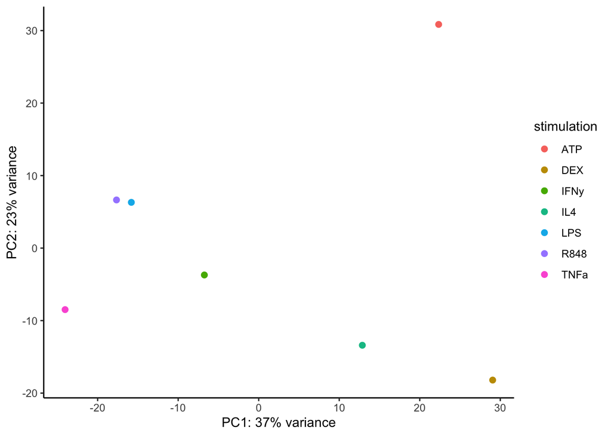

```r
dat <- data.frame(dat)
pca <- prcomp(t(dat), scale=TRUE)
PoV <- round((pca$sdev^2/sum(pca$sdev^2))*100)
#Grab covariates to plot:
library(ggplot2)
library(ggfortify)


#Plot:
ggplot(pca, aes(PC1, PC2, color=stimulation)) +
  geom_point(size=2) +
  xlab(paste0("PC1: ",PoV[1],"% variance")) +
  ylab(paste0("PC2: ",PoV[2],"% variance")) +
  theme_classic()
```

```r
list_filters = list(LPS = genes_LPS, IFNy = genes_IFNy, R848 = genes_R848, TNF = genes_TNFa, ATP = genes_ATP, DEX = genes_DEX, IL4 = genes_IL4)
#list_filters
overlap = unlist(list_filters)
```

### Upset plot

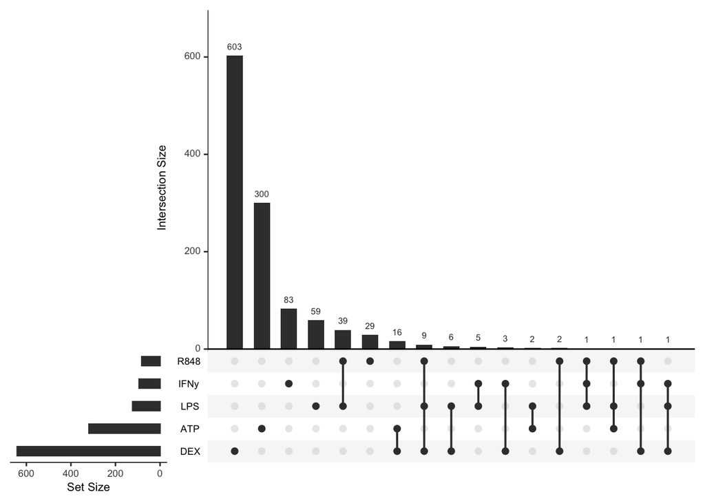

```r
upset(fromList(list_filters), order.by = "freq")
```

# DEG across stimulations FDR 5% in 2 stimulations

#3161 genes

```r
DEG_LPS <- subset(res_name_LPS2, adj.P.Val < 0.05)
DEG_IFNy <- subset(res_name_IFNy2, adj.P.Val < 0.05)
DEG_TNFa <- subset(res_name_TNFa2, adj.P.Val < 0.05)
DEG_R848 <- subset(res_name_R8482, adj.P.Val < 0.05)
DEG_ATP <- subset(res_name_ATP2, adj.P.Val < 0.05)
DEG_DEX <- subset(res_name_DEX2, adj.P.Val < 0.05)
DEG_IL4 <- subset(res_name_IL42, adj.P.Val < 0.05)

genes_LPS <- DEG_LPS$ensembl
genes_ATP <- DEG_ATP$ensembl
genes_R848 <- DEG_R848$ensembl
genes_IFNy <- DEG_IFNy$ensembl
genes_DEX <- DEG_DEX$ensembl
genes_IL4 <- DEG_IL4$ensembl
genes_TNFa <- DEG_TNFa$ensembl

# create a vector with all genes listed
x <- c(genes_LPS, genes_ATP, genes_R848, genes_IFNy, genes_DEX, genes_IL4, genes_TNFa)
# make a dataframe
as.data.frame(x) #12590 genes
# check if there are genes duplicate
duplicated(x)
x[duplicated(x)]
unique(x)
#continue only with duplicated
ensembl <- x[duplicated(x)] #4051 genes

genelist <- as.data.frame(ensembl)
#remove duplicated
ensembl <- genelist$ensembl[!duplicated(genelist$ensembl)]
genelist <- as.data.frame(ensembl) #3159 genes

DEG_genes_LPS = merge(res_name_LPS2, genelist, by ="ensembl")
DEG_genes_IFNy = merge(res_name_IFNy2, genelist, by = "ensembl")
DEG_genes_IL4 = merge(res_name_IL42, genelist, by = "ensembl")
DEG_genes_R848 = merge(res_name_R8482, genelist, by = "ensembl")
DEG_genes_ATP = merge(res_name_ATP2, genelist, by = "ensembl")
DEG_genes_DEX = merge(res_name_DEX2, genelist, by = "ensembl")
DEG_genes_TNFa = merge(res_name_TNFa2, genelist, by = "ensembl")

Expression_stimulations <- cbind(DEG_genes_LPS, DEG_genes_IFNy, DEG_genes_IL4, DEG_genes_R848, DEG_genes_ATP, DEG_genes_DEX, DEG_genes_TNFa)

as.data.frame(Expression_stimulations)
# changes names in data frame
names(Expression_stimulations)[2] <- "LPS"
names(Expression_stimulations)[10] <- "IFNy"
names(Expression_stimulations)[18] <- "IL4"
names(Expression_stimulations)[26] <- "R848"
names(Expression_stimulations)[34] <- "ATP"
names(Expression_stimulations)[42] <- "DEX"
names(Expression_stimulations)[50] <- "TNFa"

DF_log2FC <- Expression_stimulations %>% select(1, 2, 10, 18, 26, 34, 42, 50)
DF <- as.data.frame(DF_log2FC)
DF <- t(DF)
head( DF )[,1:10]

DF_log2FC <- merge(gencode, DF_log2FC, by = "ensembl")
DF_log2FC$symbol = DF_log2FC$GeneSymbol

# fill NA with 0
DF_log2FC[is.na(DF_log2FC)] = 0
#save(DF_log2FC, file = "kmeans3151gsupport.Rdata")

# remove the first column
df_num = as.matrix(DF_log2FC[,4:10])
# scale the data
df_num_scale = scale(df_num)
# make rownames as function
rownames(df_num) = sapply(DF_log2FC$symbol,function(x)
strsplit(as.character(x),split = "\\\\")[[1]][1])
save(df_num, file = "df_num_FDR0.52stim_ensembl.Rdata")
#save(df_num_scale, file = "df_num_scale_FDR0.52stim_ensembl.Rdata")
```

### Overlap 3161 genes with Patir

```r
gencode <- read.delim("~/Documents/MiGASti/Databases/ens.geneid.gencode.v30")
gencode$ensembl = gencode$gene_id
genelist <- merge(gencode, genelist, by = "ensembl")
genelist$symbol = genelist$GeneSymbol
Patir <- read.csv("~/Documents/MiGASti/Databases/Patir.txt", sep="")
names(Patir)[1] <- "symbol"
overlap2 <- merge(Patir, genelist, by = "symbol")
list(overlap2$symbol)
```

[[1]] [1] “ABI3” “ADAM28” “ADAP2” “ALOX5AP” “APBB1IP” “APOC2”  
[7] “ARHGAP25” “ARHGAP45” “ARHGDIB” “ATP8B4” “B3GNT5” “BLNK”  
[13] “C1QB” “C1QC” “C3AR1” “CASP1” “CCR1” “CD33”  
[19] “CD53” “CD69” “CD84” “CD86” “CLEC17A” “CLEC7A”  
[25] “CMKLR1” “CSF1R” “CTSC” “CXCL16” “CYFIP1” “CYTH4”  
[31] “CYTIP” “DEF6” “DOCK8” “EBI3” “EVI2B” “FCGR1A”  
[37] “FCGR2A” “FGD2” “FGL2” “GPR183” “GPR34” “HAMP”  
[43] “HAVCR2” “HCK” “HLA-DPA1” “HLA-DQB1” “HLA-DRA” “HLA-DRB1” [49] “HLA-DRB5” “IFI16” “IFI30” “IGSF6” “IL13RA1” “IL18”  
[55] “IL6R” “INPP5D” “IRF5” “IRF8” “ITGAL” “ITGAM”  
[61] “KLHL6” “LAPTM5” “LAT2” “LGALS9” “LHFPL2” “LILRB2”  
[67] “LPAR5” “LPXN” “MS4A4A” “MSR1” “NCF4” “NCKAP1L” [73] “OLFML3” “OLR1” “PARVG” “PLXDC2” “PTAFR” “PTPN6”  
[79] “PTPRC” “PYCARD” “REEP4” “RGS1” “RGS10” “RHBDF2”  
[85] “RIN3” “SAMSN1” “SCIN” “SELPLG” “SERPINA1” “SIGLEC9” [91] “SLC11A1” “SLC2A5” “SLC37A2” “SLC7A7” “SP140” “SP140L”  
[97] “SPP1” “SUCNR1” “SYK” “SYTL3” “TBXAS1” “TFEC”  
[103] “TMC8” “TMEM119” “TNFRSF1B” “TNFSF8” “TREM2” “TRIM22”  
[109] “TRIM38” “TYROBP” “VAMP8” “VAV1”

### Heatmap DEG

#3161 genes

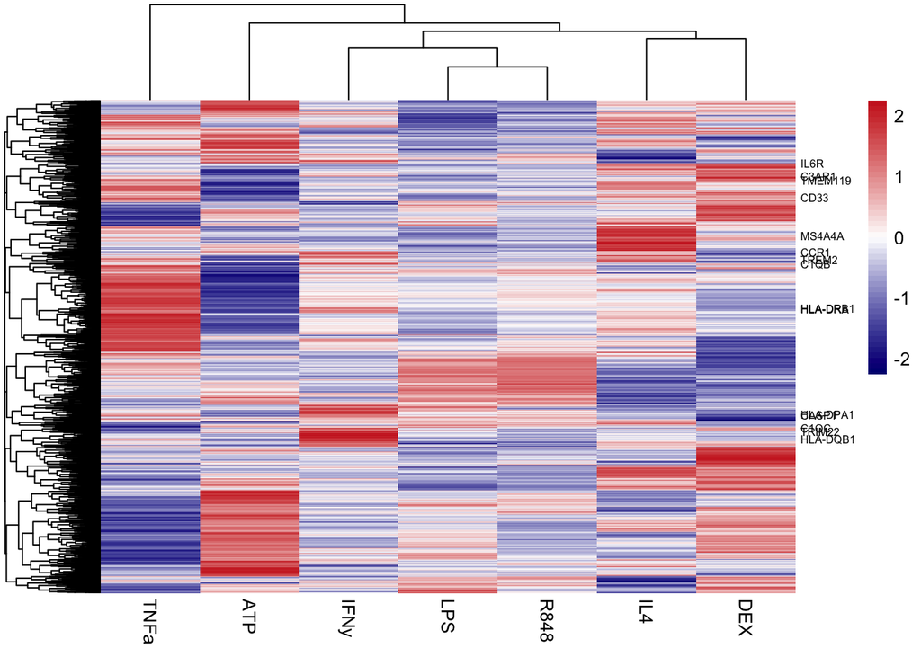

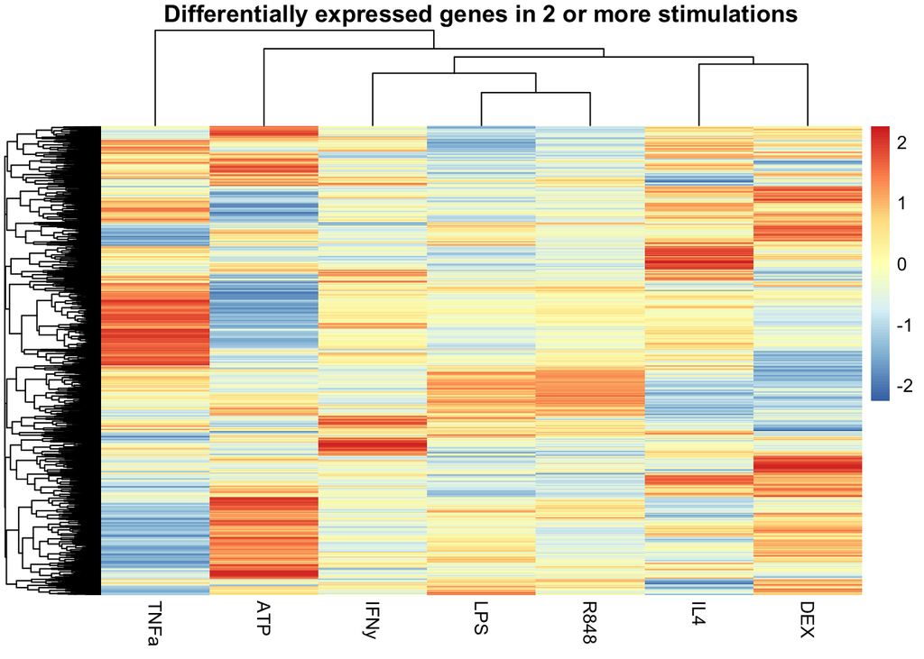

```r
rownames(DF_log2FC) = DF_log2FC$symbol
genelist <- c("C1QB", "C1QC", "C3AR1", "CASP1", "CCR1","CD33", "MS4A4A", "TREM2", "TRIM22", "TMEM119", "HLA-DPA1", "HLA-DQB1", "HLA-DRA",  "HLA-DRB1", "IL6R")

labels <- rownames(DF_log2FC)
labels[!labels %in% genelist] <- ""
pheatmap(df_num_scale, scale="row", labels_row = labels, fontsize_row = 6, color = colorRampPalette(c("navy", "white", "firebrick3"))(50))

pheatmap(df_num_scale, scale = "row", main = "Differentially expressed genes in 2 or more stimulations")
```

### Correlation plot DEG (Spearman)

#3161 genes

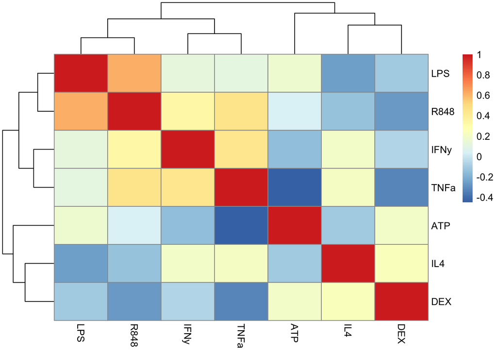

```r
com = DF_log2FC[,4:10]
cc = cor(com, method = "spearman")
pheatmap(cc)
```

### PCA across stimulations

```r
dat <- data.frame(df_num_scale)
stimulation <- colnames(dat)
as.data.frame(stimulation)
```

| stimulation |
| --- |
| LPS |
| IFNy |
| IL4 |
| R848 |
| ATP |
| DEX |
| TNFa |

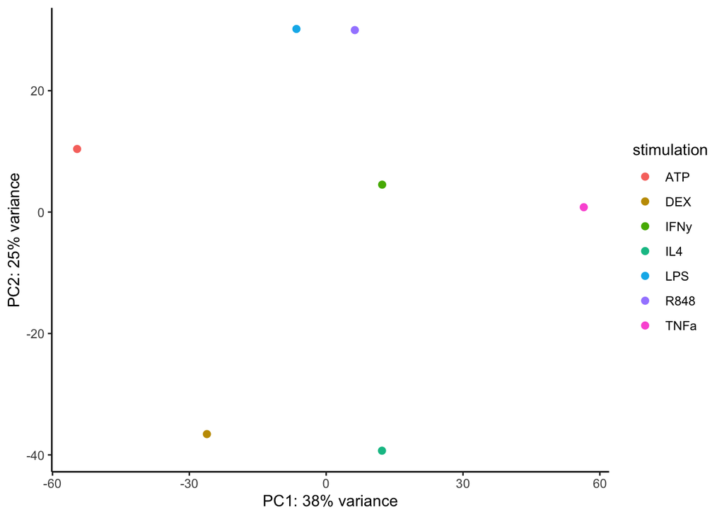

```r
dat <- data.frame(dat)
pca <- prcomp(t(dat), scale=TRUE)
PoV <- round((pca$sdev^2/sum(pca$sdev^2))*100)
#Grab covariates to plot:
library(ggplot2)
library(ggfortify)


#Plot:
ggplot(pca, aes(PC1, PC2, color=stimulation)) +
  geom_point(size=2) +
  xlab(paste0("PC1: ",PoV[1],"% variance")) +
  ylab(paste0("PC2: ",PoV[2],"% variance")) +
  theme_classic()
```

```r
list_filters = list(LPS = DEG_genes_LPS$symbol, IFNy = DEG_genes_IFNy$symbol, R848 = DEG_genes_R848$symbol, TNF = DEG_genes_TNFa$symbol, ATP = DEG_genes_ATP$symbol, DEX = DEG_genes_DEX$symbol, IL4 = DEG_genes_IL4$symbol)
#list_filters
overlap = unlist(list_filters)
```

### Upset plot

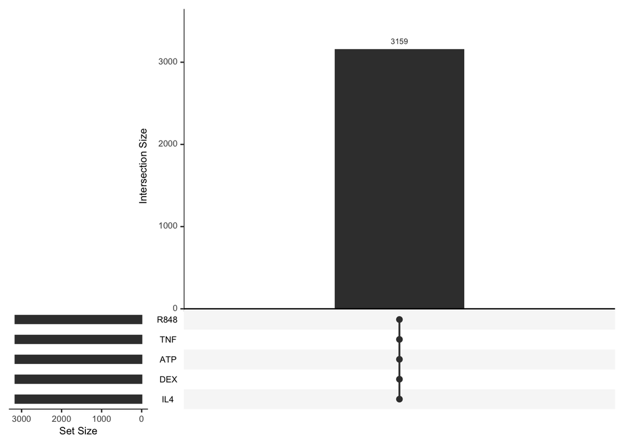

```r
upset(fromList(list_filters), order.by = "freq")
```

# DEG across stimulations FDR 5%

#8523 genes

```r
#check duplicated genes in list
#[1] "ATF7"    "TMSB15B" "POLR2J4" "MATR3"   "HSPA14"  "SCO2" "TBCE"    "ATXN7"   "ABCF2"   "POLR2J3" "GGT1"

DEG_LPS <- subset(res_name_LPS2, adj.P.Val < 0.05)
DEG_IFNy <- subset(res_name_IFNy2, adj.P.Val < 0.05)
DEG_TNFa <- subset(res_name_TNFa2, adj.P.Val < 0.05)
DEG_R848 <- subset(res_name_R8482, adj.P.Val < 0.05)
DEG_ATP <- subset(res_name_ATP2, adj.P.Val < 0.05)
DEG_DEX <- subset(res_name_DEX2, adj.P.Val < 0.05)
DEG_IL4 <- subset(res_name_IL42, adj.P.Val < 0.05)

genes_LPS <- DEG_LPS$ensembl
genes_ATP <- DEG_ATP$ensembl
genes_R848 <- DEG_R848$ensembl
genes_IFNy <- DEG_IFNy$ensembl
genes_DEX <- DEG_DEX$ensembl
genes_IL4 <- DEG_IL4$ensembl
genes_TNFa <- DEG_TNFa$ensembl

# create a vector with all genes listed
x <- c(genes_LPS, genes_ATP, genes_R848, genes_IFNy, genes_DEX, genes_IL4, genes_TNFa)
# make a dataframe
as.data.frame(x) #12590 genes
# check if there are genes duplicate
duplicated(x)
unique(x)
#remove duplicated
ensembl <- x[!duplicated(x)] #8506 genes

genelist <- as.data.frame(ensembl)
ensembl <- genelist$ensembl[!duplicated(genelist$ensembl)]
genelist <- as.data.frame(ensembl) #8506 genes
genelist %>% distinct(ensembl, .keep_all = TRUE)

DEG_genes_LPS = merge(res_name_LPS2, genelist, by ="ensembl")
DEG_genes_IFNy = merge(res_name_IFNy2, genelist, by = "ensembl")
DEG_genes_IL4 = merge(res_name_IL42, genelist, by = "ensembl")
DEG_genes_R848 = merge(res_name_R8482, genelist, by = "ensembl")
DEG_genes_ATP = merge(res_name_ATP2, genelist, by = "ensembl")
DEG_genes_DEX = merge(res_name_DEX2, genelist, by = "ensembl")
DEG_genes_TNFa = merge(res_name_TNFa2, genelist, by = "ensembl")

Expression_stimulations <- cbind(DEG_genes_LPS, DEG_genes_IFNy, DEG_genes_IL4, DEG_genes_R848, DEG_genes_ATP, DEG_genes_DEX, DEG_genes_TNFa)

as.data.frame(Expression_stimulations)
# changes names in data frame
names(Expression_stimulations)[2] <- "LPS"
names(Expression_stimulations)[10] <- "IFNy"
names(Expression_stimulations)[18] <- "IL4"
names(Expression_stimulations)[26] <- "R848"
names(Expression_stimulations)[34] <- "ATP"
names(Expression_stimulations)[42] <- "DEX"
names(Expression_stimulations)[50] <- "TNFa"

DF_log2FC <- Expression_stimulations %>% select(1, 2, 10, 18, 26, 34, 42, 50)
DF <- as.data.frame(DF_log2FC)
DF <- t(DF)
head( DF )[,1:10]


# fill NA with 0
DF_log2FC[is.na(DF_log2FC)] = 0
#save(DF_log2FC, file = "kmeans8523ensembl.Rdata")

DF_log2FC <- merge(gencode, DF_log2FC, by = "ensembl")
DF_log2FC$symbol = DF_log2FC$GeneSymbol

#remove rownames that are duplicates (GGT1, HSPA14)
DF_log2FC = DF_log2FC[-c(1122, 6885),]

# remove the first column
df_num = as.matrix(DF_log2FC[,4:10])
# scale the data
df_num_scale = scale(df_num)
# make rownames as function
rownames(df_num) = sapply(DF_log2FC$symbol,function(x)
strsplit(as.character(x),split = "\\\\")[[1]][1])
save(df_num, file = "df_num_FDR0.5stim_allgenes.ensembl.Rdata")
#save(DF_log2FC, file = "FDR0.5_stimulations_allgenes.Rdata")
#save(df_num_scale, file = "df_num_scale_FDR0.5stim_allgenes_ensembl.Rdata")
```

### Overlap 8523 genes with Patir

```r
gencode <- read.delim("~/Documents/MiGASti/Databases/ens.geneid.gencode.v30")
gencode$ensembl = gencode$gene_id
genelist <- merge(gencode, genelist, by = "ensembl")
genelist$symbol = genelist$GeneSymbol
Patir <- read.csv("~/Documents/MiGASti/Databases/Patir.txt", sep="")
names(Patir)[1] <- "symbol"
overlap2 <- merge(Patir, genelist, by = "symbol")
list(overlap2$symbol)
```

[[1]] [1] “ABCC4” “ABI3” “ADAM28” “ADAP2” “ADORA3” “ADRB2”  
[7] “AIF1” “ALOX5AP” “AOAH” “APBB1IP” “APOC2” “ARHGAP15” [13] “ARHGAP25” “ARHGAP45” “ARHGDIB” “ARPC1B” “ATP8B4” “B3GNT5”  
[19] “BIN2” “BLNK” “BTK” “C1QB” “C1QC” “C2”  
[25] “C3AR1” “CASP1” “CCR1” “CD14” “CD300A” “CD33”  
[31] “CD37” “CD4” “CD53” “CD68” “CD69” “CD74”  
[37] “CD84” “CD86” “CIITA” “CLEC17A” “CLEC7A” “CMKLR1”  
[43] “CSF1R” “CSF2RA” “CTSC” “CTSS” “CXCL16” “CYBB”  
[49] “CYFIP1” “CYTH4” “CYTIP” “DEF6” “DHRS9” “DOCK2”  
[55] “DOCK8” “EBI3” “ELF4” “EVI2B” “FCGR1A” “FCGR1B”  
[61] “FCGR2A” “FGD2” “FGL2” “FPR1” “FYB1” “GAL3ST4”  
[67] “GIMAP2” “GIMAP4” “GMFG” “GPR183” “GPR34” “HAMP”  
[73] “HAVCR2” “HCK” “HCLS1” “HCST” “HHEX” “HK2”  
[79] “HLA-DMA” “HLA-DMB” “HLA-DOA” “HLA-DPA1” “HLA-DPB1” “HLA-DQA1” [85] “HLA-DQB1” “HLA-DRA” “HLA-DRB1” “HLA-DRB5” “HPGDS” “IFI16”  
[91] “IFI30” “IGSF6” “IKZF1” “IL10RA” “IL13RA1” “IL18”  
[97] “IL6R” “INPP5D” “IRF5” “IRF8” “ITGAL” “ITGAM”  
[103] “ITGAX” “ITGB2” “KLHL6” “LAPTM5” “LAT2” “LCP2”  
[109] “LGALS9” “LHFPL2” “LILRB1” “LILRB2” “LPAR5” “LPAR6”  
[115] “LPXN” “LY75” “LY86” “LYL1” “MAFB” “MILR1”  
[121] “MNDA” “MPEG1” “MS4A4A” “MS4A7” “MSR1” “MYO1F”  
[127] “NAGA” “NCF4” “NCKAP1L” “OLFML3” “OLR1” “OSM”  
[133] “P2RY12” “PARVG” “PIK3AP1” “PIK3CG” “PLXDC2” “PPP1R18”  
[139] “PTAFR” “PTPN6” “PTPRC” “PYCARD” “RBM47” “REEP4”  
[145] “RGS1” “RGS10” “RHBDF2” “RIN3” “RNASE6” “RNASET2”  
[151] “SAMSN1” “SASH3” “SCIN” “SELPLG” “SERPINA1” “SIGLEC10” [157] “SIGLEC11” “SIGLEC7” “SIGLEC9” “SIRPB2” “SLC11A1” “SLC15A3”  
[163] “SLC2A5” “SLC37A2” “SLC7A7” “SP140” “SP140L” “SPP1”  
[169] “SRGN” “ST6GAL1” “STAB1” “SUCNR1” “SYK” “SYTL3”  
[175] “TAL1” “TBXAS1” “TFEC” “TLR1” “TLR2” “TLR3”  
[181] “TLR6” “TMC8” “TMEM106A” “TMEM119” “TNFAIP8L2” “TNFRSF1B” [187] “TNFSF8” “TRAF3IP3” “TREM2” “TRIM22” “TRIM38” “TYROBP”  
[193] “VAMP8” “VAV1” “WAS” “WDFY4”

### Heatmap DEG

#8521 genes

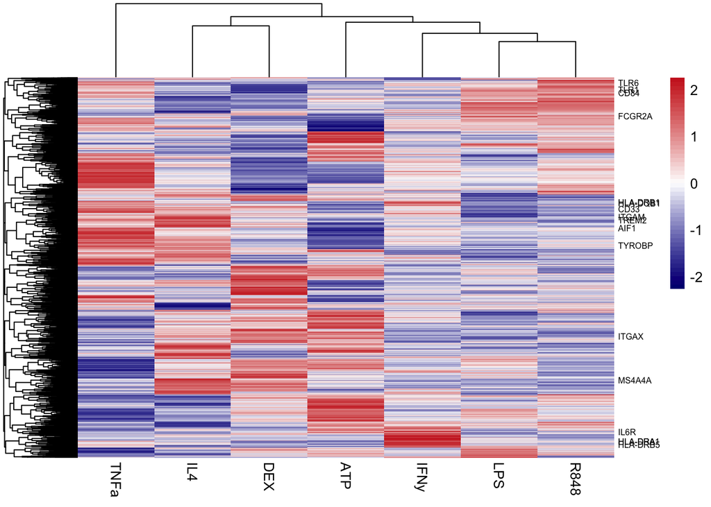

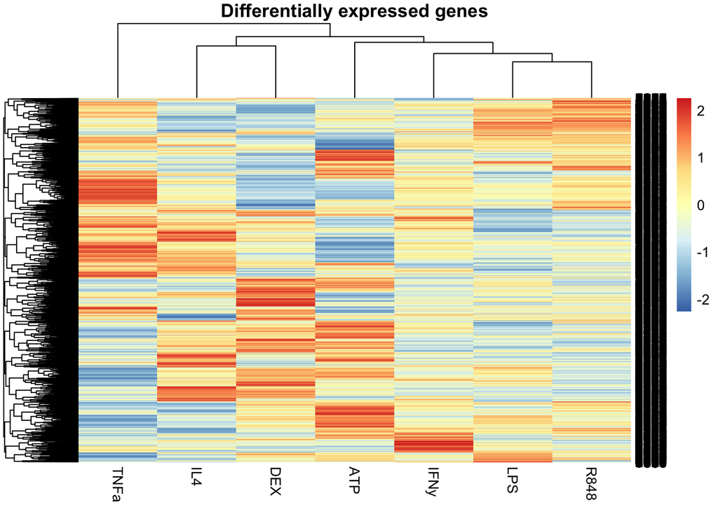

```r
rownames(DF_log2FC) = DF_log2FC$symbol
genelist <- c("CD33", "MS4A4A", "TREM2", "TYROBP", "TLR1", "HLA-DPA1", "HLA-DQB1", "HLA-DRA",  "HLA-DRB1", "IL6R", "TLR6", "FCGR2A", "AIF1", "ITGAX", "ITGAM", "HLA-DRB5" , "CD84")

labels <- rownames(DF_log2FC)
labels[!labels %in% genelist] <- ""
pheatmap(df_num_scale, scale="row", labels_row = labels, fontsize_row = 6, color = colorRampPalette(c("navy", "white", "firebrick3"))(50))

pheatmap(df_num_scale, scale = "row", main = "Differentially expressed genes")
```

### Correlation plot DEG (Spearman)

#8523

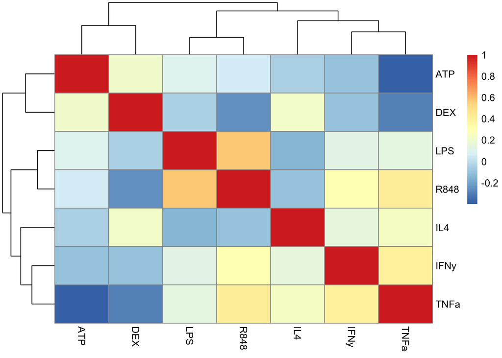

```r
com = DF_log2FC[,4:10]
cc = cor(com, method = "spearman")
pheatmap(cc)
```

### PCA across stimulations

```r
dat <- data.frame(df_num_scale)
stimulation <- colnames(dat)
as.data.frame(stimulation)
```

| stimulation |
| --- |
| LPS |
| IFNy |
| IL4 |
| R848 |
| ATP |
| DEX |
| TNFa |

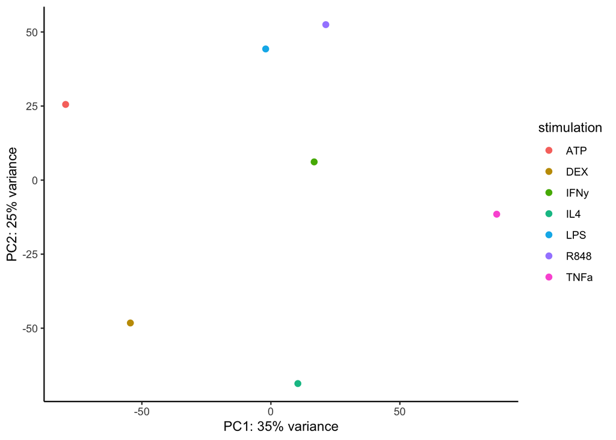

```r
dat <- data.frame(dat)
pca <- prcomp(t(dat), scale=TRUE)
PoV <- round((pca$sdev^2/sum(pca$sdev^2))*100)
#Grab covariates to plot:
library(ggplot2)
library(ggfortify)


#Plot:
ggplot(pca, aes(PC1, PC2, color=stimulation)) +
  geom_point(size=2) +
  xlab(paste0("PC1: ",PoV[1],"% variance")) +
  ylab(paste0("PC2: ",PoV[2],"% variance")) +
  theme_classic()
```

```r
list_filters = list(LPS = genes_LPS, IFNy = genes_IFNy, R848 = genes_R848, TNF = genes_TNFa, ATP = genes_ATP, DEX = genes_DEX, IL4 = genes_IL4)
#list_filters
overlap = unlist(list_filters)
```

### Upset plot

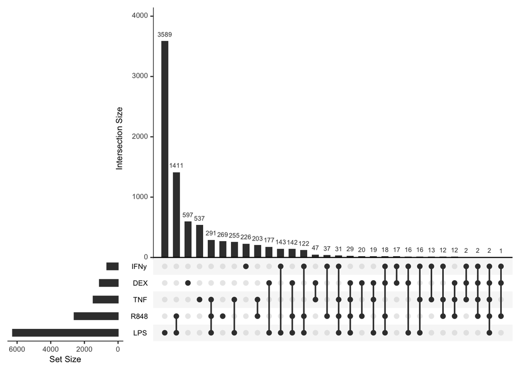

```r
upset(fromList(list_filters), order.by = "freq")
```

# Scatterplots

### LogFC LPS vs IFNy

#18981 genes

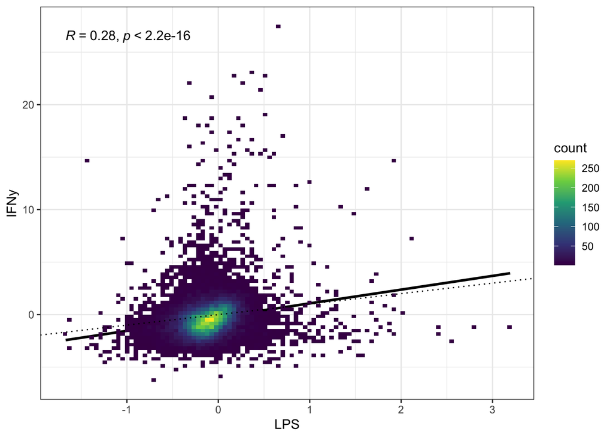

```r
names(res_name_LPS2)[2] <- "LPS"
names(res_name_IFNy2)[2] <- "IFNy"
DEG_genes_LPS_IFNy = merge(res_name_LPS2, res_name_IFNy2, by ="symbol")

LPS <- DEG_genes_LPS_IFNy[,3]
IFNy <- DEG_genes_LPS_IFNy[,12]
df = data.frame(LPS, IFNy)
p <- ggplot(df, aes(x=LPS, y=IFNy) ) +
  geom_smooth(method = "lm", se=FALSE, color="black", formula = y ~ x) +
  geom_bin2d(bins = 100) +
  geom_abline(slope = 1, intercept = 0, linetype = 3) +
  scale_fill_continuous(type = "viridis") +
  theme_bw()
p + stat_cor(method = "spearman")
```

### LogFC LPS vs R848

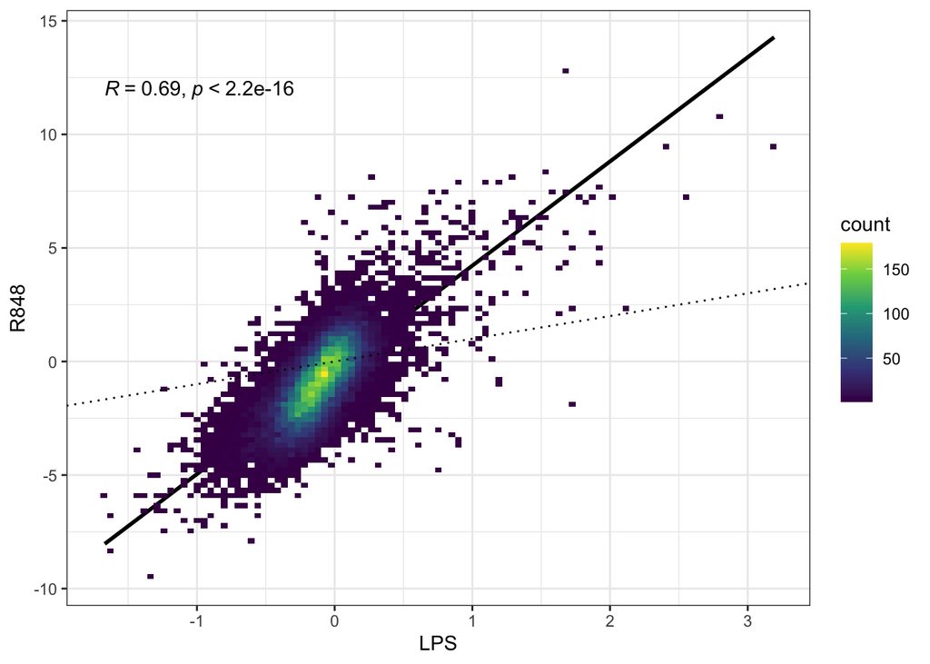

```r
names(res_name_LPS2)[2] <- "LPS"
names(res_name_R8482)[2] <- "R848"
DEG_genes_LPS_R848 = merge(res_name_LPS2, res_name_R8482, by ="symbol")

LPS <- DEG_genes_LPS_R848[,3]
R848 <- DEG_genes_LPS_R848[,12]
df = data.frame(LPS, R848)
p <- ggplot(df, aes(x=LPS, y=R848) ) +
  geom_smooth(method = "lm", se=FALSE, color="black", formula = y ~ x) +
  geom_bin2d(bins = 100) +
  geom_abline(slope = 1, intercept = 0, linetype = 3) +
  scale_fill_continuous(type = "viridis") +
  theme_bw()
p + stat_cor(method = "spearman")
```

### LogFC LPS vs TNFa

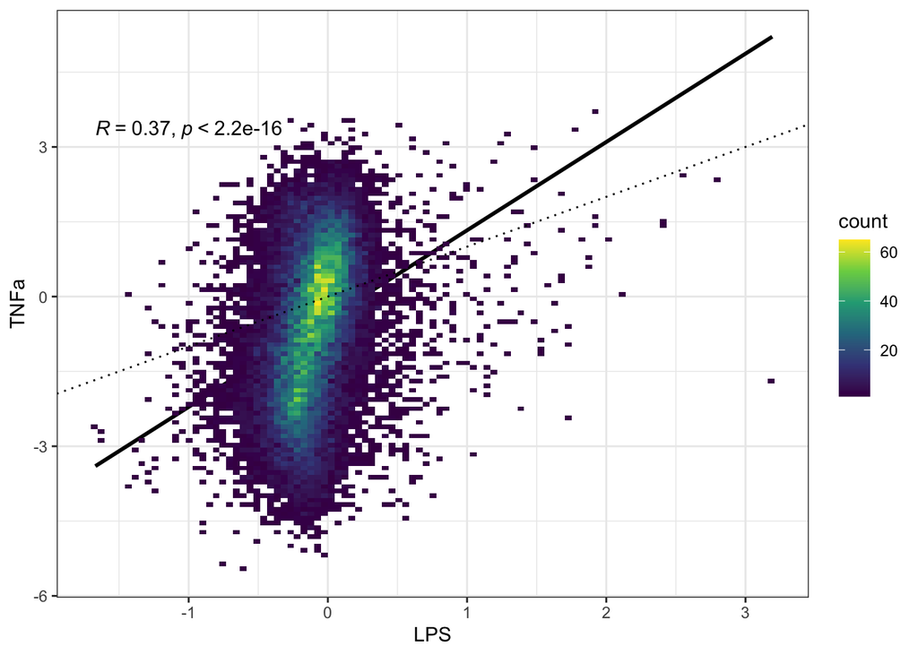

```r
names(res_name_LPS2)[2] <- "LPS"
names(res_name_TNFa2)[2] <- "TNFa"
DEG_genes_LPS_TNFa = merge(res_name_LPS2, res_name_TNFa2, by ="symbol")

LPS <- DEG_genes_LPS_TNFa[,3]
TNFa <- DEG_genes_LPS_TNFa[,12]
df = data.frame(LPS, TNFa)
p <- ggplot(df, aes(x=LPS, y=TNFa) ) +
  geom_smooth(method = "lm", se=FALSE, color="black", formula = y ~ x) +
  geom_bin2d(bins = 100) +
  geom_abline(slope = 1, intercept = 0, linetype = 3) +
  scale_fill_continuous(type = "viridis") +
  theme_bw()
p + stat_cor(method = "spearman")
```

### LogFC LPS vs DEX

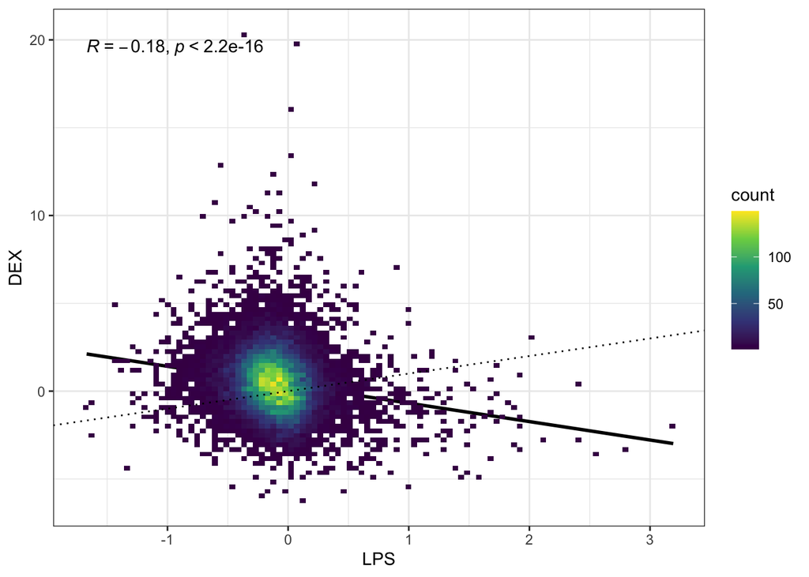

```r
names(res_name_LPS2)[2] <- "LPS"
names(res_name_DEX2)[2] <- "DEX"
DEG_genes_LPS_DEX = merge(res_name_LPS2, res_name_DEX2, by ="symbol")

LPS <- DEG_genes_LPS_DEX[,3]
DEX <- DEG_genes_LPS_DEX[,12]
df = data.frame(LPS, DEX)
p <- ggplot(df, aes(x=LPS, y=DEX) ) +
  geom_smooth(method = "lm", se=FALSE, color="black", formula = y ~ x) +
  geom_bin2d(bins = 100) +
  geom_abline(slope = 1, intercept = 0, linetype = 3) +
  scale_fill_continuous(type = "viridis") +
  theme_bw()
p + stat_cor(method = "spearman")
```

### LogFC LPS vs IL4

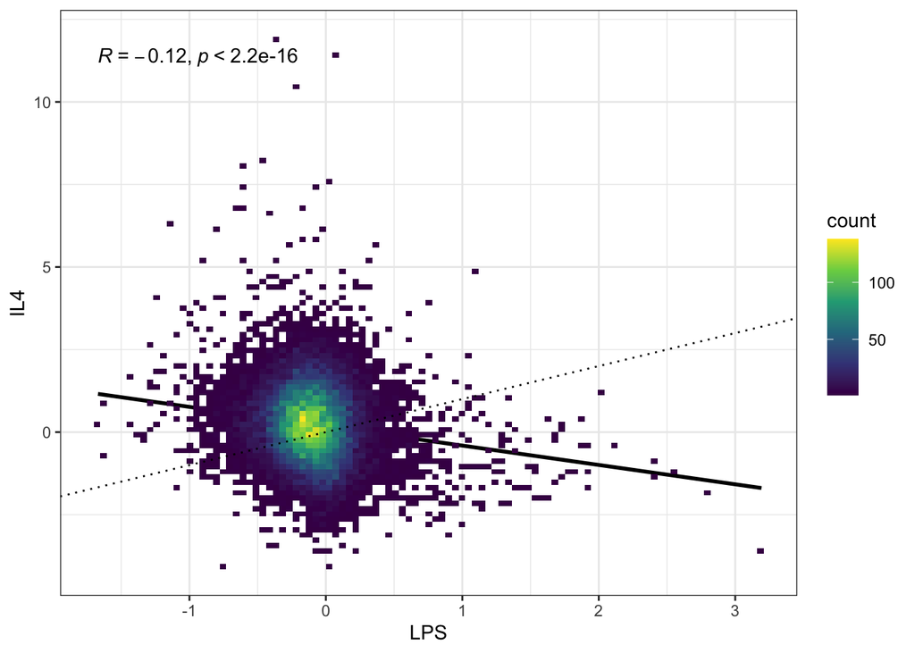

```r
names(res_name_LPS2)[2] <- "LPS"
names(res_name_IL42)[2] <- "IL4"
DEG_genes_LPS_IL4 = merge(res_name_LPS2, res_name_IL42, by ="symbol")

LPS <- DEG_genes_LPS_IL4[,3]
IL4 <- DEG_genes_LPS_IL4[,12]
df = data.frame(LPS, IL4)
p <- ggplot(df, aes(x=LPS, y=IL4) ) +
  geom_smooth(method = "lm", se=FALSE, color="black", formula = y ~ x) +
  geom_bin2d(bins = 100) +
  geom_abline(slope = 1, intercept = 0, linetype = 3) +
  scale_fill_continuous(type = "viridis") +
  theme_bw()
p + stat_cor(method = "spearman")
```

### LogFC LPS vs ATP

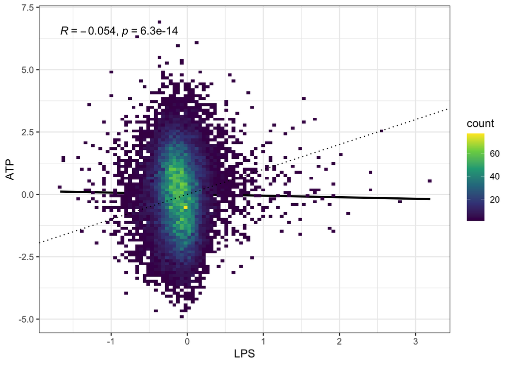

```r
names(res_name_LPS2)[2] <- "LPS"
names(res_name_ATP2)[2] <- "ATP"
DEG_genes_LPS_ATP = merge(res_name_LPS2, res_name_ATP2, by ="symbol")

LPS <- DEG_genes_LPS_ATP[,3]
ATP <- DEG_genes_LPS_ATP[,12]
df = data.frame(LPS, ATP)
p <- ggplot(df, aes(x=LPS, y=ATP) ) +
  geom_smooth(method = "lm", se=FALSE, color="black", formula = y ~ x) +
  geom_bin2d(bins = 100) +
  geom_abline(slope = 1, intercept = 0, linetype = 3) +
  scale_fill_continuous(type = "viridis") +
  theme_bw()
p + stat_cor(method = "spearman")
```